# LOAN APPROVAL PREDICTION

STEP 1: READIND AND UNDERSTANDING THE DATA

```r
# Clear the memory and check the path for the data
rm(list=ls())
getwd()
```

```
[1] "C:/Users/hp/Desktop/Projects/loan prediction using machine learning"
```

```r
# Change the path to the desired one
setwd("C:\\Users\\hp\\Desktop\\Projects\\loan prediction using machine learning")
getwd()
```

```
[1] "C:/Users/hp/Desktop/Projects/loan prediction using machine learning"
```

```r
# Read the data and print the first 6 variables
data = read.csv("loan-train.csv")
head(data)
```

|  | Loan_ID | Gender | Married | Dependents | Education | Self_Employed | ApplicantIncome | CoapplicantIncome | LoanAmount | Loan_Amount_Term | Credit_History | Property_Area | Loan_Status |
| --- | --- | --- | --- | --- | --- | --- | --- | --- | --- | --- | --- | --- | --- |
| 1 | LP001002 | Male | No | 0 | Graduate | No | 5849 | 0 | NA | 360 | 1 | Urban | Y |
| 2 | LP001003 | Male | Yes | 1 | Graduate | No | 4583 | 1508 | 128 | 360 | 1 | Rural | N |
| 3 | LP001005 | Male | Yes | 0 | Graduate | Yes | 3000 | 0 | 66 | 360 | 1 | Urban | Y |
| 4 | LP001006 | Male | Yes | 0 | Not Graduate | No | 2583 | 2358 | 120 | 360 | 1 | Urban | Y |
| 5 | LP001008 | Male | No | 0 | Graduate | No | 6000 | 0 | 141 | 360 | 1 | Urban | Y |
| 6 | LP001011 | Male | Yes | 2 | Graduate | Yes | 5417 | 4196 | 267 | 360 | 1 | Urban | Y |

```r
# Import the necessary libraries
library(dplyr)
library(tidyverse)
library(ggplot2)
library(stargazer)
```

```r
# view the stracture of our dataset
str(data)
```

```
'data.frame':   614 obs. of  13 variables:
 $ Loan_ID          : chr  "LP001002" "LP001003" "LP001005" "LP001006" ...
 $ Gender           : chr  "Male" "Male" "Male" "Male" ...
 $ Married          : chr  "No" "Yes" "Yes" "Yes" ...
 $ Dependents       : chr  "0" "1" "0" "0" ...
 $ Education        : chr  "Graduate" "Graduate" "Graduate" "Not Graduate" ...
 $ Self_Employed    : chr  "No" "No" "Yes" "No" ...
 $ ApplicantIncome  : int  5849 4583 3000 2583 6000 5417 2333 3036 4006 12841 ...
 $ CoapplicantIncome: num  0 1508 0 2358 0 ...
 $ LoanAmount       : int  NA 128 66 120 141 267 95 158 168 349 ...
 $ Loan_Amount_Term : int  360 360 360 360 360 360 360 360 360 360 ...
 $ Credit_History   : int  1 1 1 1 1 1 1 0 1 1 ...
 $ Property_Area    : chr  "Urban" "Rural" "Urban" "Urban" ...
 $ Loan_Status      : chr  "Y" "N" "Y" "Y" ...
```

```r
# summarize the dataset in a table format
stargazer(data, type = "text")
```

```
==========================================================
Statistic          N    Mean    St. Dev.   Min     Max
----------------------------------------------------------
ApplicantIncome   614 5,403.459 6,109.042  150    81,000
CoapplicantIncome 614 1,621.246 2,926.248 0.000 41,667.000
LoanAmount        592  146.412   85.587     9      700
Loan_Amount_Term  600  342.000   65.120    12      480
Credit_History    564   0.842     0.365     0       1
----------------------------------------------------------
```

```r
summary(data)
```

```
   Loan_ID             Gender            Married           Dependents         Education
 Length:614         Length:614         Length:614         Length:614         Length:614
 Class :character   Class :character   Class :character   Class :character   Class :character
 Mode  :character   Mode  :character   Mode  :character   Mode  :character   Mode  :character




 Self_Employed      ApplicantIncome CoapplicantIncome   LoanAmount    Loan_Amount_Term
 Length:614         Min.   :  150   Min.   :    0     Min.   :  9.0   Min.   : 12
 Class :character   1st Qu.: 2878   1st Qu.:    0     1st Qu.:100.0   1st Qu.:360
 Mode  :character   Median : 3812   Median : 1188     Median :128.0   Median :360
                    Mean   : 5403   Mean   : 1621     Mean   :146.4   Mean   :342
                    3rd Qu.: 5795   3rd Qu.: 2297     3rd Qu.:168.0   3rd Qu.:360
                    Max.   :81000   Max.   :41667     Max.   :700.0   Max.   :480
                                                      NA's   :22      NA's   :14
 Credit_History   Property_Area      Loan_Status
 Min.   :0.0000   Length:614         Length:614
 1st Qu.:1.0000   Class :character   Class :character
 Median :1.0000   Mode  :character   Mode  :character
 Mean   :0.8422
 3rd Qu.:1.0000
 Max.   :1.0000
 NA's   :50
```

STEP 2: DATA CLEANING. First we check for missing values.

```r
# Lets check for missing values
any(is.na(data))
```

```
[1] TRUE
```

We have missing values. lets check how many missing values do we have

```r
sum(is.na(data))
```

```
[1] 86
```

```r
# now, we check if we have empty entries and convert them to NA
colSums(is.na(data)|data == "")
```

```
          Loan_ID            Gender           Married        Dependents         Education
                0                13                 3                15                 0
    Self_Employed   ApplicantIncome CoapplicantIncome        LoanAmount  Loan_Amount_Term
               32                 0                 0                22                14
   Credit_History     Property_Area       Loan_Status
               50                 0                 0
```

```r
# gender, married, dependents,Self_Employed, LoanAmount, Loan_Amount_Term and Credit_History have emty entries. we then convert them to NA
data[data == ""] = NA
sum(is.na(data))
```

```
[1] 149
```

We then handle the missing values

```r
data2 = na.omit(data)
sum(is.na(data2))
```

```
[1] 0
```

We have no missing valus, nesxt we deal with datatypes

```r
# first, we convert character variable to factor form
data3 =  as.data.frame(unclass(data2), stringsAsFactors = TRUE)
data3$Credit_History = as.factor(data3$Credit_History)
str(data3)
```

```
'data.frame':   480 obs. of  13 variables:
 $ Loan_ID          : Factor w/ 480 levels "LP001003","LP001005",..: 1 2 3 4 5 6 7 8 9 10 ...
 $ Gender           : Factor w/ 2 levels "Female","Male": 2 2 2 2 2 2 2 2 2 2 ...
 $ Married          : Factor w/ 2 levels "No","Yes": 2 2 2 1 2 2 2 2 2 2 ...
 $ Dependents       : Factor w/ 4 levels "0","1","2","3+": 2 1 1 1 3 1 4 3 2 3 ...
 $ Education        : Factor w/ 2 levels "Graduate","Not Graduate": 1 1 2 1 1 2 1 1 1 1 ...
 $ Self_Employed    : Factor w/ 2 levels "No","Yes": 1 2 1 1 2 1 1 1 1 1 ...
 $ ApplicantIncome  : int  4583 3000 2583 6000 5417 2333 3036 4006 12841 3200 ...
 $ CoapplicantIncome: num  1508 0 2358 0 4196 ...
 $ LoanAmount       : int  128 66 120 141 267 95 158 168 349 70 ...
 $ Loan_Amount_Term : int  360 360 360 360 360 360 360 360 360 360 ...
 $ Credit_History   : Factor w/ 2 levels "0","1": 2 2 2 2 2 2 1 2 2 2 ...
 $ Property_Area    : Factor w/ 3 levels "Rural","Semiurban",..: 1 3 3 3 3 3 2 3 2 3 ...
 $ Loan_Status      : Factor w/ 2 levels "N","Y": 1 2 2 2 2 2 1 2 1 2 ...
```

Now lets check for duplicates

```r
duplicates = duplicated(data3)|duplicated(data3, fromlast = TRUE)
any(duplicates)
```

```
[1] FALSE
```

The data is now clean for analysis

STEP 3: DATA VISUALIZATION (EDA)

```r
# Combine columns for income
data4 = data3 %>% mutate(income = data3$ApplicantIncome + data3$CoapplicantIncome)
head(data4)
```

|  | Loan_ID | Gender | Married | Dependents | Education | Self_Employed | ApplicantIncome | CoapplicantIncome | LoanAmount | Loan_Amount_Term | Credit_History | Property_Area | Loan_Status | income |
| --- | --- | --- | --- | --- | --- | --- | --- | --- | --- | --- | --- | --- | --- | --- |
| 1 | LP001003 | Male | Yes | 1 | Graduate | No | 4583 | 1508 | 128 | 360 | 1 | Rural | N | 6091 |
| 2 | LP001005 | Male | Yes | 0 | Graduate | Yes | 3000 | 0 | 66 | 360 | 1 | Urban | Y | 3000 |
| 3 | LP001006 | Male | Yes | 0 | Not Graduate | No | 2583 | 2358 | 120 | 360 | 1 | Urban | Y | 4941 |
| 4 | LP001008 | Male | No | 0 | Graduate | No | 6000 | 0 | 141 | 360 | 1 | Urban | Y | 6000 |
| 5 | LP001011 | Male | Yes | 2 | Graduate | Yes | 5417 | 4196 | 267 | 360 | 1 | Urban | Y | 9613 |
| 6 | LP001013 | Male | Yes | 0 | Not Graduate | No | 2333 | 1516 | 95 | 360 | 1 | Urban | Y | 3849 |

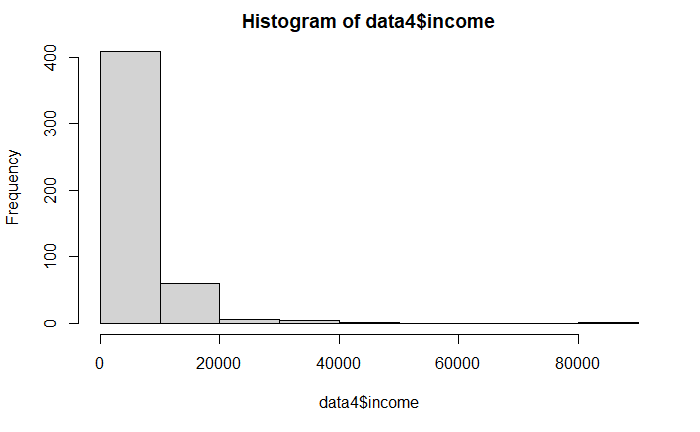

```r
# Now lets check the distribution for income
hist(data4$income)
```

We can see that income is not normally distributed, ie, it is right skewed. Most of the data tend to lie below 20000

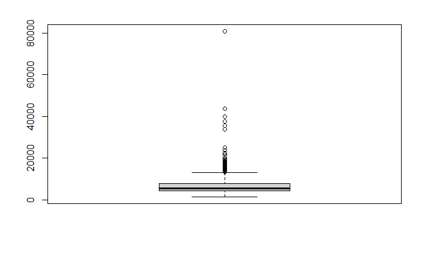

```r
# Visualizing the boxplot
boxplot(data4$income)
```

The variable income has also some outliers. lets try to handle the case for outliers and normality by using logarithmic transformation.

```r
data5 = data4 %>% mutate(income_transformed = log(income))
head(data5)
```

|  | Loan_ID | Gender | Married | Dependents | Education | Self_Employed | ApplicantIncome | CoapplicantIncome | LoanAmount | Loan_Amount_Term | Credit_History | Property_Area | Loan_Status | income | income_transformed |
| --- | --- | --- | --- | --- | --- | --- | --- | --- | --- | --- | --- | --- | --- | --- | --- |
| 1 | LP001003 | Male | Yes | 1 | Graduate | No | 4583 | 1508 | 128 | 360 | 1 | Rural | N | 6091 | 8.714568 |
| 2 | LP001005 | Male | Yes | 0 | Graduate | Yes | 3000 | 0 | 66 | 360 | 1 | Urban | Y | 3000 | 8.006368 |
| 3 | LP001006 | Male | Yes | 0 | Not Graduate | No | 2583 | 2358 | 120 | 360 | 1 | Urban | Y | 4941 | 8.505323 |
| 4 | LP001008 | Male | No | 0 | Graduate | No | 6000 | 0 | 141 | 360 | 1 | Urban | Y | 6000 | 8.699515 |
| 5 | LP001011 | Male | Yes | 2 | Graduate | Yes | 5417 | 4196 | 267 | 360 | 1 | Urban | Y | 9613 | 9.170872 |
| 6 | LP001013 | Male | Yes | 0 | Not Graduate | No | 2333 | 1516 | 95 | 360 | 1 | Urban | Y | 3849 | 8.255569 |

check the privious distribution

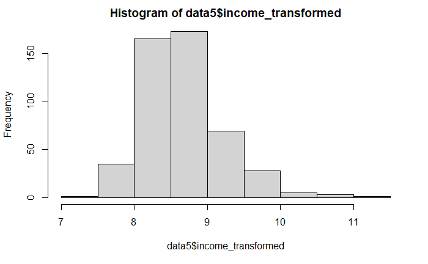

```r
hist(data5$income_transformed)
```

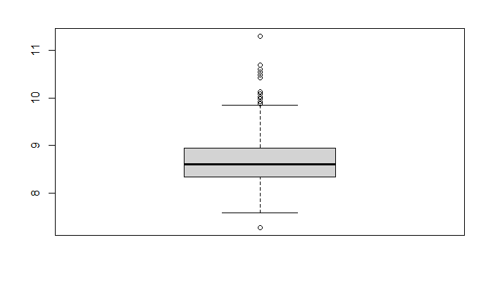

```r
boxplot(data5$income_transformed)
```

Income now looks to be normal with a reduced number of outliers lets check some other sitributions

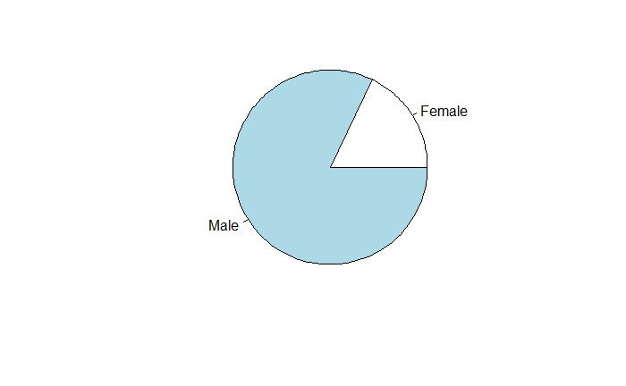

```r
pie(table(data5$Gender))
```

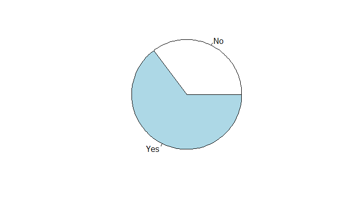

```r
pie(table(data5$Married))
```